# Supplementary Figure 2: RIG-I-only vs STAT-only signatures in virus-infected single cells (CHIKV and SARS-CoV-2)

Carlos Ramirez

2026-10-27 17:03:46

This markdown reproduces the two panels of **Supplementary Figure 2**. We project the RIG-I-only and STAT-only (IFN-only) signatures, derived from the A549 cell model in `figure_01.Rmd`, onto two virus-infection single-cell RNA-Seq datasets by computing per-cell module scores (`Seurat::AddModuleScore`):

1. **`plots_chikv.pdf`** — human fibroblasts infected with chikungunya virus (CHIKV; [Pott F et al., 2021](https://www.ncbi.nlm.nih.gov/geo/query/acc.cgi?acc=GSE176361), GEO GSE176361) at 6 and 24 hours post infection (hpi). Top: scatter plot of RIG-I-only vs STAT-only scores per cell, coloured by the viral-RNA level category of the cell (mock, bystander = `no_chikv`, `low_chikv`; the `high_chikv` cells are excluded), with the RIG-I-only = 0.15 threshold used to define “RIG-I-high” cells. Bottom: among RIG-I-high cells, IFNB1 expression (left) and log CHIKV-nsp expression (right) per time point and viral-RNA category (Kruskal-Wallis p-values).
2. **`scatterplot_rigi_vs_stat_ravindra.pdf`** — SARS-CoV-2-infected human bronchial epithelial cells (HBEC air-liquid interface cultures; [Ravindra NG et al., 2021, PLoS Biol](https://journals.plos.org/plosbiology/article?id=10.1371/journal.pbio.3001143), GEO GSE166766). RIG-I-only vs STAT-only scores of the SARS-CoV-2-positive cells (`scv2+ == 1`), coloured by IFNL1 expression and faceted by cell type.

Code is taken from the original analysis scripts (`/media/ag-cherrmann/cramirez/interferon_model/scripts/R/july_2026/03_scRNASeq_chinkonkunia_dataset.Rmd` and `/media/ag-cherrmann/cramirez/interferon_model/scripts/R/july_2026/figure_03_scRNASeq_projections_ravindra.Rmd`), keeping only what is needed for these two panels. Plotting code and PDF sizes are unchanged.

```r
library(dplyr)
library(ggplot2)
library(Seurat)
library(viridis)
library(scales)
library(ggpubr)
library(patchwork)

source("/media/bq-storage/ag-cherrmann/cramirez/decoupling_rigi_ifn/scripts/R/settings.R")
```

## Settings

Output folders of this section: PDFs go to `figures/supplementary_figure_02/` and intermediate tables to `analysis/supplementary_figure_02/` of the repo.

```r
dirs <- section_dirs("supplementary_figure_02")
path2figures  <- dirs$figures
path2analysis <- dirs$analysis

knitr::opts_chunk$set(
  message = FALSE,
  warning = FALSE,
  error = FALSE
)
```

## Input data

All inputs are read-only; nothing is written next to them.

[output not shown]

Cell metadata used:

- **CHIKV objects** (from the GEO objects): `timepoint` (`6hpi`, `24hpi`), `chikrnalvl` (viral-RNA level category: `mock`, `no_chikv`, `low_chikv`, `high_chikv`), and the viral genes `CHIKV-nsp` (non-structural) and `CHIKV-sp` (structural) as features, plus host `IFNB1`.
- **Ravindra object**: `scv2+` (1 = SARS-CoV-2-positive cell), `ctype` (cell type), `percent.mt` (recomputed below for QC), and host `IFNL1`.

The Ileum organoid data loaded at the top of the original Ravindra script (`/home/bq_cramirez/sds-hd/sd21e005/cramirez/organoids/data/COVID19_July.rda`) is **not** used by this panel (it only feeds a different figure, `rigi_vs_stat_signatures.pdf`), and is not loaded here.

## Loading signatures

As in the original scripts, IFNB/IFNL genes are removed from the signatures (they are the read-out we want to compare against) and the list is reordered to `stat_only`, `rigi_only`.

```r
signatures <- readRDS(path2signs)
signatures <- lapply(signatures,
                     function(genes){
                             genes[!grepl('IFNB|IFNL', genes)]
})
signatures <- signatures[c(2,1)]
str(signatures)
```

```
## List of 2
##  $ stat_only: chr [1:99] "PNPT1" "TRIM5" "CSF1" "ZNF711" ...
##  $ rigi_only: chr [1:94] "EGR4" "CXCL11" "FOSB" "EGR2" ...
```

# Panel: CHIKV-infected fibroblasts (`plots_chikv.pdf`)

## Loading the CHIKV 6 hpi data

The original script decompressed the `.rds.gz` GEO file next to the data (the `gunzip()` call, commented out). The decompressed file already exists in the data folder, so we read it directly and never write there.

```r
path2chikv6hpi <- "/media/bq-storage/ag-cherrmann/cramirez/data/GSE176361_chkv_2021/GSE176361_integrated_6hpi.rds.gz"
#gunzip(
#  path2chikv6hpi,
#  destname = sub("\\.gz$", "", path2chikv6hpi),
#  overwrite = FALSE
#)
path_rds <- sub("\\.gz$", "", path2chikv6hpi)
obj_chikv6hpi <- readRDS(path_rds)
obj_chikv6hpi
```

```
## An object of class Seurat
## 53910 features across 47041 samples within 3 assays
## Active assay: SCT (23781 features, 0 variable features)
##  3 layers present: counts, data, scale.data
##  2 other assays present: RNA, integrated
##  2 dimensional reductions calculated: pca, umap
```

## Scoring the cells (6 hpi)

Signature genes are restricted to those present in the `SCT` assay of the 6 hpi object; the same gene lists are used for 24 hpi. Module scores are computed fresh here (the GEO object does not contain these scores).

```r
# Make sure the genes are present in the assay
stat_genes <- intersect(signatures$stat_only, rownames(obj_chikv6hpi[["SCT"]]))
rigi_genes <- intersect(signatures$rigi_only, rownames(obj_chikv6hpi[["SCT"]]))

obj_chikv6hpi <- AddModuleScore(
    object = obj_chikv6hpi,
    features = list(stat_genes, rigi_genes),
    assay = "SCT",
    name = c("STAT_only", "RIGI_only")
)
```

## Loading and scoring the CHIKV 24 hpi data

```r
path2chikv24hpi <- "/media/bq-storage/ag-cherrmann/cramirez/data/GSE176361_chkv_2021/GSE176361_integrated_24hpi.rds.gz"
#gunzip(
#  path2chikv24hpi,
#  destname = sub("\\.gz$", "", path2chikv24hpi),
#  overwrite = FALSE
#)
path_rds <- sub("\\.gz$", "", path2chikv24hpi)
obj_chikv24hpi <- readRDS(path_rds)

obj_chikv24hpi <- AddModuleScore(
    object = obj_chikv24hpi,
    features = list(stat_genes, rigi_genes),
    assay = "SCT",
    name = c("STAT_only", "RIGI_only")
)
```

## Combining the scores of both time points

The per-cell scores, viral-RNA category, CHIKV-nsp and IFNB1 expression of both time points are combined and saved to `analysis/supplementary_figure_02/`.

```r
scores <- rbind(
            FetchData(obj_chikv6hpi,
                      vars = c("chikrnalvl", "timepoint",
                               "STAT_only1", "RIGI_only2",
                               "CHIKV-nsp", "IFNB1")),
            FetchData(obj_chikv24hpi,
                      vars = c("chikrnalvl", "timepoint",
                               "STAT_only1", "RIGI_only2",
                               "CHIKV-nsp", "IFNB1"))
)

saveRDS(scores, file.path(path2analysis, "chikv_cell_scores.rds"))

rm(obj_chikv6hpi, obj_chikv24hpi); invisible(gc())
```

## Scatter plot (top of `plots_chikv.pdf`)

RIG-I-only vs STAT-only scores coloured by viral-RNA category; `high_chikv` cells are excluded. The colour vector `chikrnalvl_cols` is defined here (in the original script it was defined in a later chunk, i.e. the PDF was produced from an interactive session with the colours already in memory).

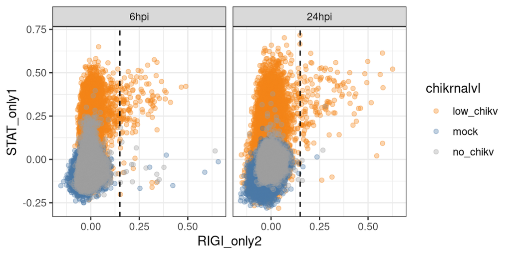

```r
chikrnalvl_cols <- c(
  "mock"      = "#4C78A8",  # blue
  "no_chikv"  = "#9E9E9E",  # gray
  "low_chikv" = "#F58518"   # orange
)

scatterplot_chikv <- scores %>%
        mutate(timepoint=factor(timepoint,
                                levels = c("6hpi", "24hpi"))
               ) %>%
        filter(chikrnalvl != "high_chikv") %>%
        arrange(chikrnalvl) %>%
        ggplot(aes(x=RIGI_only2,
                   y=STAT_only1,
                   colour=chikrnalvl)) +
                geom_point(alpha=0.35,
                           size=1.5) +
                geom_vline(xintercept = 0.15,
                           colour="black",
                           linetype="dashed") +
                facet_wrap(~timepoint) +
                        theme_bw() +
                scale_colour_manual(values = chikrnalvl_cols)

scatterplot_chikv
```

## Boxplots of RIG-I-high cells (bottom of `plots_chikv.pdf`)

Cells with RIG-I-only score > 0.15 are called RIG-I-high. For these cells we compare IFNB1 expression and log CHIKV-nsp expression across viral-RNA categories (Kruskal-Wallis test per time point).

```r
scores <- mutate(scores,
                 rigi_level=ifelse(RIGI_only2>0.15,
                        "High", "Low"))

boxplot_chikv <- scores %>%
    mutate(
        timepoint = factor(timepoint,
                           levels = c("6hpi", "24hpi"))
    ) %>%
    filter(
        rigi_level == "High",
        chikrnalvl != "high_chikv"
    ) %>%
    ggplot(aes(x = timepoint,
               y = log(`CHIKV-nsp`),
               fill = chikrnalvl)) +
    geom_boxplot() +
    stat_compare_means(
        method = "kruskal.test",
        label = "p.format"
    ) +
        scale_fill_manual(values = chikrnalvl_cols) +
    labs(
        x = "",
        y = "CHIKV-nsp gene expression"
    ) +
    theme_classic()


boxplot_ifnb1 <- scores %>%
    mutate(
        timepoint = factor(timepoint,
                           levels = c("6hpi", "24hpi"))
    ) %>%
    filter(
        rigi_level == "High",
        chikrnalvl != "high_chikv"
    ) %>%
    ggplot(aes(x = timepoint,
               y = IFNB1,
               fill = chikrnalvl)) +
    geom_boxplot() +
        scale_fill_manual(values = chikrnalvl_cols) +
    stat_compare_means(
        method = "kruskal.test",
        label = "p.format"
    ) +
    labs(
        x = "",
        y = "IFNB1 gene expression"
    ) +
    theme_classic()
```

## Saving `plots_chikv.pdf`

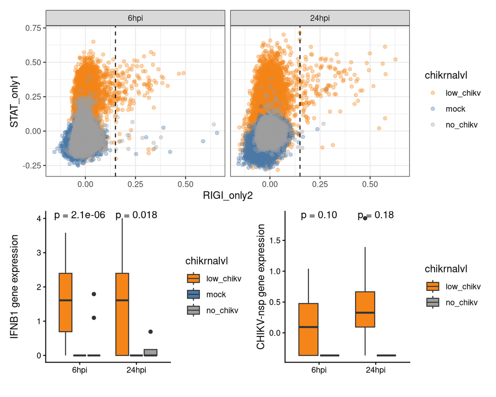

```r
scatterplot_chikv / ( boxplot_ifnb1 |  boxplot_chikv )
```

```r
pdf(paste0(path2figures, "/plots_chikv.pdf"),
    height=6.0, width=7.5)
scatterplot_chikv / ( boxplot_ifnb1 |  boxplot_chikv )
dev.off()
```

# Panel: SARS-CoV-2-infected HBECs, Ravindra et al. (`scatterplot_rigi_vs_stat_ravindra.pdf`)

## Loading data

```r
seurat <- readRDS(file = paste0(path2project,
                   '/data/ravindra_single_cells_processed/ravindra_processed_seurat.rds'))
seurat
```

```
## An object of class Seurat
## 23602 features across 76930 samples within 1 assay
## Active assay: RNA (23602 features, 0 variable features)
##  4 layers present: counts.GSM5082289_mock, counts.GSM5082290_1dpi, counts.GSM5082291_2dpi, counts.GSM5082292_3dpi
```

## Pre-processing

Cells with > 20% mitochondrial reads are removed and the counts are log-normalised (`NormalizeData`), which is what `AddModuleScore` and `FetchData(..., "IFNL1")` use (`data` layer).

```r
seurat[["percent.mt"]] <- PercentageFeatureSet(seurat,
                                                 pattern = "^MT-")

# QC filtering
seurat_filtered <- subset(seurat, percent.mt < 20)

# Normalization
seurat_filtered <- NormalizeData(seurat_filtered)

rm(seurat); invisible(gc())
```

The original script additionally ran `FindVariableFeatures()` and `ScaleData()`. Neither the module scores (computed on the `data` layer) nor the plotted IFNL1 values depend on them, so they are kept here for reference but not evaluated (`eval=FALSE`).

```r
# Find variable features
seurat_filtered <- FindVariableFeatures(seurat_filtered,
                                 selection.method = "vst",
                                 nfeatures = 5000)

# Scaling
seurat_filtered <- ScaleData(seurat_filtered,
                             features = c(VariableFeatures(seurat_filtered),
                                          "IFNB1"))
```

## Scoring Ravindra cells

```r
seurat_filtered <- AddModuleScore(
  object = seurat_filtered,
  features = signatures,
  name = names(signatures)
)
```

## Scatter plot of infected cells (`scatterplot_rigi_vs_stat_ravindra.pdf`)

RIG-I-only (`rigi_only2`) vs STAT-only (`stat_only1`) scores of SARS-CoV-2-positive cells, coloured by IFNL1 expression and faceted by cell type. The per-cell table is saved to `analysis/supplementary_figure_02/`.

```r
md_ravindra <- FetchData(seurat_filtered,
                         vars = colnames(seurat_filtered@meta.data))


markers_df <- FetchData(seurat_filtered, vars = 'IFNL1')
md_ravindra_subset <- md_ravindra[rownames(markers_df),]

all(rownames(md_ravindra_subset) == rownames(markers_df))
```

```
## [1] TRUE
```

```r
md_ravindra_subset <- cbind(md_ravindra_subset, markers_df)

saveRDS(md_ravindra_subset[, c("sample", "ctype", "scv2+", "percent.mt",
                               "stat_only1", "rigi_only2", "IFNL1")],
        file.path(path2analysis, "ravindra_cell_scores.rds"))

projection_ravindra <- md_ravindra_subset %>%
        arrange(IFNL1) %>%
  mutate(
    Infection_status = ifelse(`scv2+` == 1, "Infected", "Non-Infected")
  ) %>%
        filter(Infection_status == 'Infected') %>%
        dplyr::arrange(desc(Infection_status)) %>%
  ggplot(aes(
    x = rigi_only2,
    y = stat_only1,
    color = IFNL1
  )) +
  geom_hline(yintercept = 0, linetype = "dashed", color = "black") +
  geom_vline(xintercept = 0, linetype = "dashed", color = "black") +
  geom_point() +
        scale_colour_viridis() +
  scale_x_continuous(
    name = "RIG-I–only score",
    breaks = scales::pretty_breaks(n = 3)
  ) +
  scale_y_continuous(
    name = "STAT-only score",
    breaks = scales::pretty_breaks(n = 3)
  ) +
  facet_wrap(~ ctype) +
  theme_classic() +
  theme(
    legend.title = element_blank(),
    strip.background = element_blank(),
    strip.text = element_text(size = 10)
  )


pdf(paste0(path2figures,
           "/scatterplot_rigi_vs_stat_ravindra.pdf"),
    width=7, height=5)
projection_ravindra
dev.off()
```

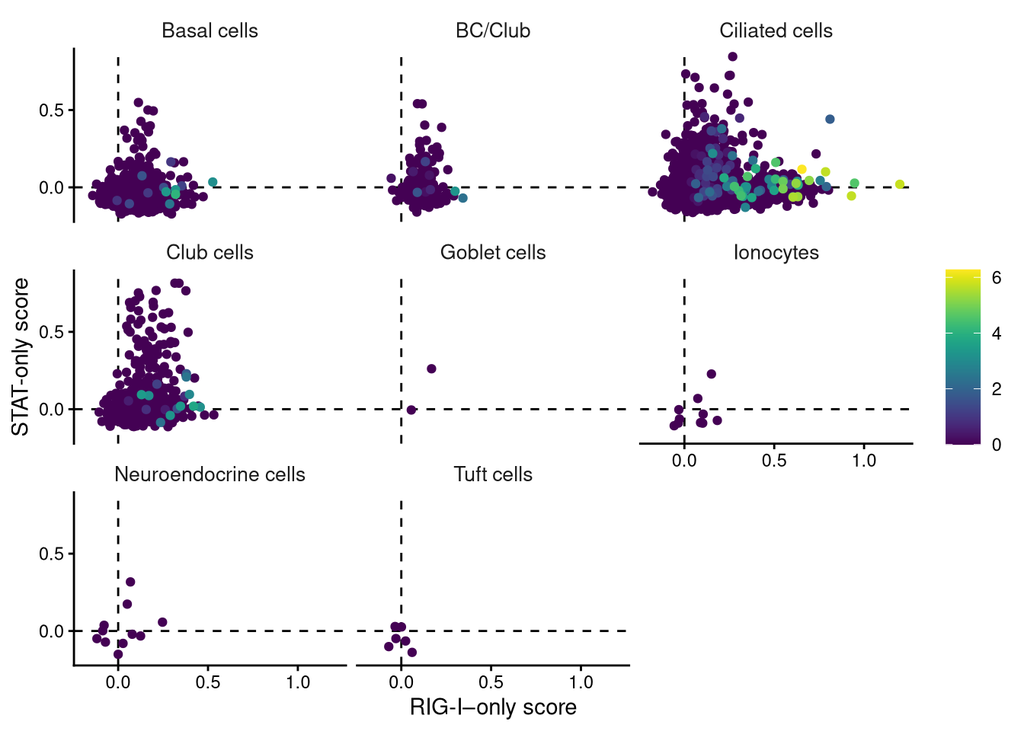

```r
projection_ravindra
```